# C04_assignment

# Setup

As always, we start by running our setup function. Start RStudio/R, and reload your project with the menu `File > Recent Projects`.

```r
source("setup.R")
```

# Load data - choose a month and sampling approach

Let’s load what we need to build a model” the configuration and the complete covariate data. Notice that we (a) transform month to a simple numeric value (it’s easier to work with as a number) and (b) select the covariates that are included in our configuration plus “class”.

You may also catch that we log scale `depth` and `Xbtm`. This reduces the numeric range of each to be more comparable to those of the other covariates. This is a common trick when dealing with data that ranges over orders of magnitude compared to companion data.

```r
cfg = read_configuration(scientificname = "Mustelus canis", version = "v1")
model_input = read_model_input(scientificname = "Mustelus canis",
                               version = "v1",
                               log_me = c("depth", "Xbtm")) |>
  dplyr::mutate(month = month_as_number(.data$month)) |>
  select(all_of(c("class", cfg$keep)))
```

# Splitting the data into groups

Here we want to split the data into two groups: data for training the model during creation and data for testing the model after we have created it. We’ll aim for 80% of the data to train on and reserving 20% of the data for later testing.

After that, we want to split the **training** data so that we have groups, or “folds”, across the spatial domain. This will look approximately like a checkerboard where we (potentially) have a balance of observations and background represented, but it is possible to have strong imbalance in any of the checkerboard squares. That’s OK.

## Initial split into training and testing groups

```r
model_input_split = spatial_initial_split(model_input,
                        prop = 1 / 5,     # 20% for testing
                        strategy = spatial_block_cv) # see ?spatial_block_cv
model_input_split
```

```
## <Training/Testing/Total>
## <3528/515/4043>
```

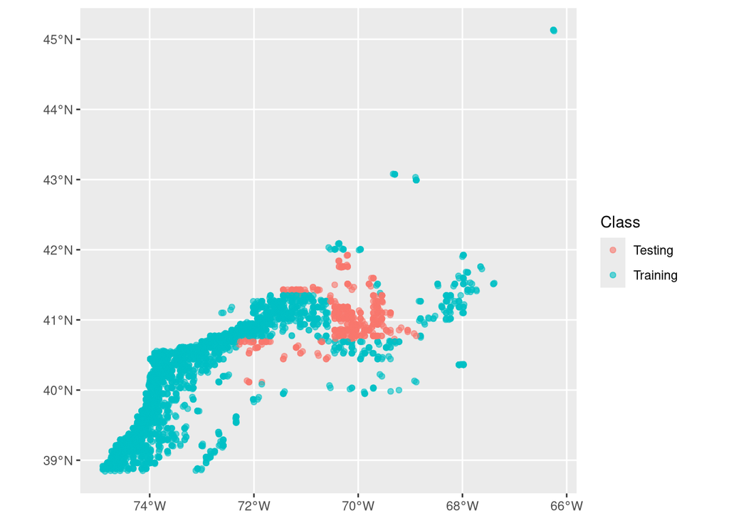

```r
autoplot(model_input_split)
```

## Split the training group into regional folds

Next we take just the **training** data and split that into a set cross-validation folds. We do this to improve our model by making multiple spatially distributed training mini-datasets.

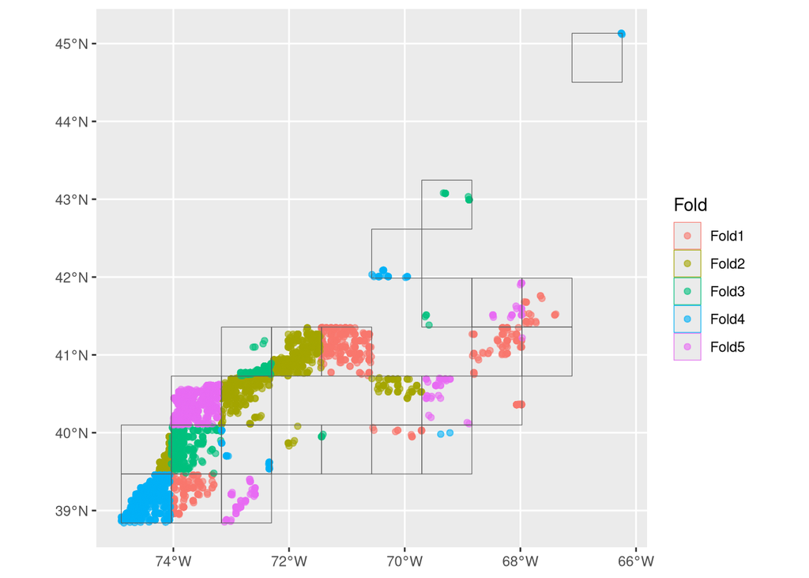

```r
tr_data = training(model_input_split)
cv_tr_data <- spatial_block_cv(tr_data,
  v = 5,
  cellsize = grid_cellsize(model_input),
  offset = grid_offset(model_input) + 0.00001
)
autoplot(cv_tr_data)
```

```r
one_row_of_training_data = dplyr::slice(tr_data,1)
rec = recipe(one_row_of_training_data, formula = class ~ .)
rec
```

```
## ── Recipe ──────────────────────────────────────────────────────────────────────
```

```
## ── Inputs
```

```
## Number of variables by role
```

```
## outcome:   1
## predictor: 9
## coords:    2
```

This print out provides a very high level summary - all of the details are glossed over. To get a more detailed summary use the `summary()` function. Note that the coordinates (longitude and latitude) are detected and labeled as `coords` and not predictors. There are ways around that if you need to use longitude or latitude as predictor variables.

```r
summary(rec)
```

```
## # A tibble: 12 × 4
##    variable type      role      source
##    <chr>    <list>    <chr>     <chr>
##  1 depth    <chr [2]> predictor original
##  2 month    <chr [2]> predictor original
##  3 SSS      <chr [2]> predictor original
##  4 U        <chr [2]> predictor original
##  5 Sbtm     <chr [2]> predictor original
##  6 V        <chr [2]> predictor original
##  7 Tbtm     <chr [2]> predictor original
##  8 MLD      <chr [2]> predictor original
##  9 SST      <chr [2]> predictor original
## 10 X        <chr [2]> coords    original
## 11 Y        <chr [2]> coords    original
## 12 class    <chr [3]> outcome   original
```

```r
wflow = workflow_set(

  preproc = list(default = rec), # not much happening in our preprocessor

  models = list(                 # but we have 4 models to add

      # very simple - nothing to tune
      glm = logistic_reg(
          mode = "classification") |>
        set_engine("glm"),

      # two knobs to tune
      rf = rand_forest(
          mtry = tune(),
          trees = tune(),
          mode = "classification") |>
        set_engine("ranger",
                   importance = "impurity"),

      # so many things to tune!
      btree = boost_tree(
          mtry = tune(),
          trees = tune(),
          tree_depth = tune(),
          learn_rate = tune(),
          loss_reduction = tune(),
          stop_iter = tune(),
          mode = "classification") |>
        set_engine("xgboost"),

      # just two again
      maxent = maxent(
          feature_classes = tune(),
          regularization_multiplier = tune(),
          mode = "classification") |>
        set_engine("maxnet")
  )
)
wflow
```

```
## # A workflow set/tibble: 4 × 4
##   wflow_id       info             option    result
##   <chr>          <list>           <list>    <list>
## 1 default_glm    <tibble [1 × 4]> <opts[0]> <list [0]>
## 2 default_rf     <tibble [1 × 4]> <opts[0]> <list [0]>
## 3 default_btree  <tibble [1 × 4]> <opts[0]> <list [0]>
## 4 default_maxent <tibble [1 × 4]> <opts[0]> <list [0]>
```

```r
metrics = sdm_metric_set(yardstick::accuracy)
metrics
```

```
## A metric set, consisting of:
## - `boyce_cont()`, a probability metric | direction: maximize
## - `roc_auc()`, a probability metric    | direction: maximize
## - `tss_max()`, a probability metric    | direction: maximize
## - `accuracy()`, a class metric         | direction: maximize
```

```r
wflow <- wflow |>
  workflow_map("tune_grid",
    resamples = cv_tr_data,
    grid = 3,
    metrics = metrics,
    verbose = TRUE)
```

```
## i    No tuning parameters. `fit_resamples()` will be attempted
```

```
## i 1 of 4 resampling: default_glm
```

```
## ✔ 1 of 4 resampling: default_glm (866ms)
```

```
## i 2 of 4 tuning:     default_rf
```

```
## i Creating pre-processing data to finalize 1 unknown parameter: "mtry"
```

```
## ✔ 2 of 4 tuning:     default_rf (1m 16.7s)
```

```
## i 3 of 4 tuning:     default_btree
```

```
## i Creating pre-processing data to finalize 1 unknown parameter: "mtry"
```

```
## → A | warning: `early_stop` was reduced to 0.
```

[output not shown]

Here’s a quick plot of the outputs, with each metric being showcased.

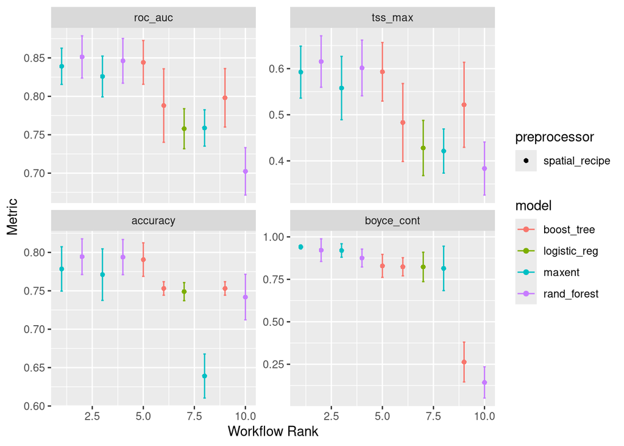

```r
autoplot(wflow)
```

```r
model_fits = workflowset_selectomatic(wflow, model_input_split,
                                  filename = "Mustelus_canis-v1-model_fits",
                                  path = data_path("models"))
model_fits
```

```
## # A tibble: 4 × 7
##   wflow_id    splits             id    .metrics .notes   .predictions .workflow
##   <chr>       <list>             <chr> <list>   <list>   <list>       <list>
## 1 default_glm <split [3528/515]> trai… <tibble> <tibble> <tibble>     <workflow>
## 2 default_rf  <split [3528/515]> trai… <tibble> <tibble> <tibble>     <workflow>
## 3 default_bt… <split [3528/515]> trai… <tibble> <tibble> <tibble>     <workflow>
## 4 default_ma… <split [3528/515]> trai… <tibble> <tibble> <tibble>     <workflow>
```

```r
model_fit_metrics(model_fits)
```

```
## # A tibble: 4 × 5
##   wflow_id       accuracy boyce_cont roc_auc tss_max
##   <chr>             <dbl>      <dbl>   <dbl>   <dbl>
## 1 default_glm       0.753      0.976   0.808   0.509
## 2 default_rf        0.804      0.635   0.881   0.716
## 3 default_btree     0.806      0.362   0.874   0.653
## 4 default_maxent    0.821      0.859   0.876   0.689
```

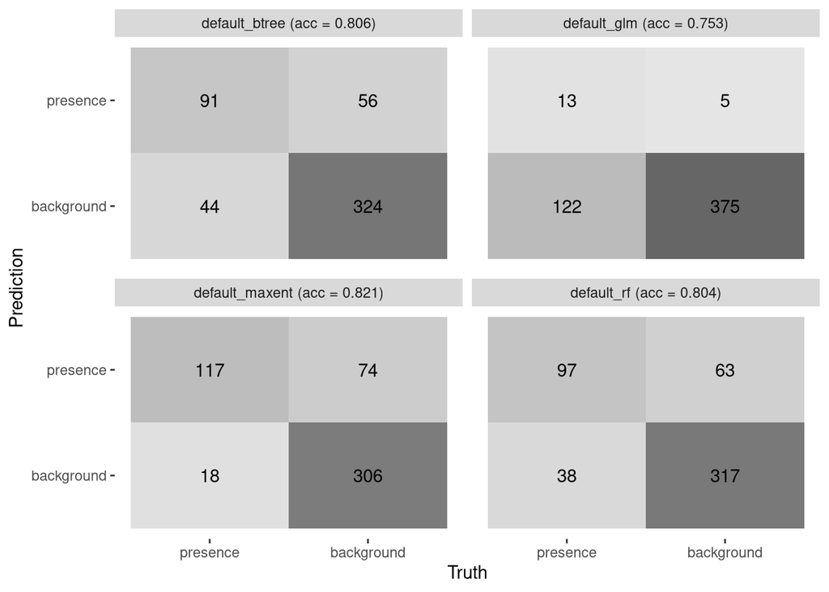

```r
model_fit_confmat(model_fits)
```

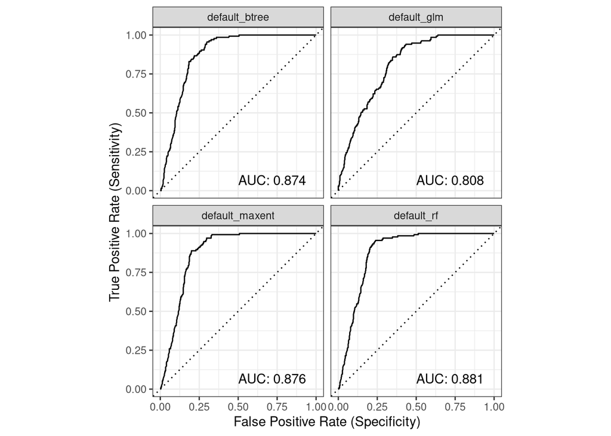

```r
model_fit_roc_auc(model_fits)
```

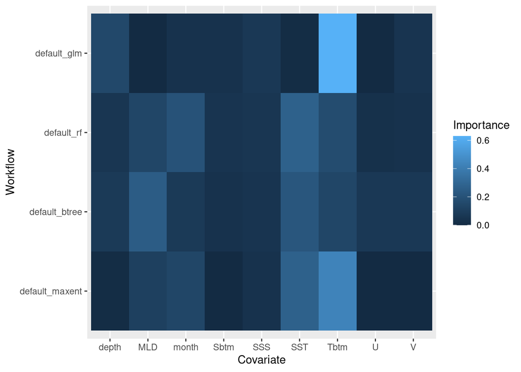

```r
model_fit_varimp_plot(model_fits)
```

```r
rf = model_fits |>
  filter(wflow_id == "default_rf")
rf
```

```
## # A tibble: 1 × 7
##   wflow_id   splits             id     .metrics .notes   .predictions .workflow
##   <chr>      <list>             <chr>  <list>   <list>   <list>       <list>
## 1 default_rf <split [3528/515]> train… <tibble> <tibble> <tibble>     <workflow>
```

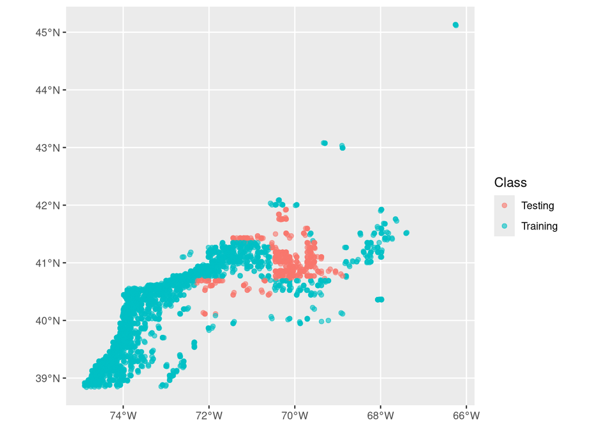

```r
autoplot(rf$splits[[1]])
```

```r
rf$.metrics[[1]]
```

```
## # A tibble: 4 × 4
##   .metric    .estimator .estimate .config
##   <chr>      <chr>          <dbl> <chr>
## 1 accuracy   binary         0.804 pre0_mod0_post0
## 2 boyce_cont binary         0.635 pre0_mod0_post0
## 3 roc_auc    binary         0.881 pre0_mod0_post0
## 4 tss_max    binary         0.716 pre0_mod0_post0
```

```r
rf$.predictions[[1]]
```

```
## # A tibble: 515 × 6
##    class      .pred_class .pred_presence .pred_background  .row .config
##    <fct>      <fct>                <dbl>            <dbl> <int> <chr>
##  1 background background         0.00954            0.990    27 pre0_mod0_post0
##  2 background background         0.0145             0.986    45 pre0_mod0_post0
##  3 background background         0.0129             0.987    50 pre0_mod0_post0
##  4 background background         0.0228             0.977    59 pre0_mod0_post0
##  5 background background         0.0261             0.974    63 pre0_mod0_post0
##  6 background background         0.00503            0.995    71 pre0_mod0_post0
##  7 background background         0.00890            0.991    81 pre0_mod0_post0
##  8 background background         0.0105             0.989    96 pre0_mod0_post0
##  9 background background         0.0174             0.983    97 pre0_mod0_post0
## 10 background background         0.0476             0.952   111 pre0_mod0_post0
## # ℹ 505 more rows
```

```r
rf$.workflow[[1]]
```

```
## ══ Workflow [trained] ══════════════════════════════════════════════════════════
## Preprocessor: Recipe
## Model: rand_forest()
##
## ── Preprocessor ────────────────────────────────────────────────────────────────
## 0 Recipe Steps
##
## ── Model ───────────────────────────────────────────────────────────────────────
## Ranger result
##
## Call:
##  ranger::ranger(x = maybe_data_frame(x), y = y, mtry = min_cols(~1L,      x), num.trees = ~2000L, importance = ~"impurity", num.threads = 1,      verbose = FALSE, seed = sample.int(10^5, 1), probability = TRUE)
##
## Type:                             Probability estimation
## Number of trees:                  2000
## Sample size:                      3528
## Number of independent variables:  9
## Mtry:                             1
## Target node size:                 10
## Variable importance mode:         impurity
## Splitrule:                        gini
## OOB prediction error (Brier s.):  0.1841738
```

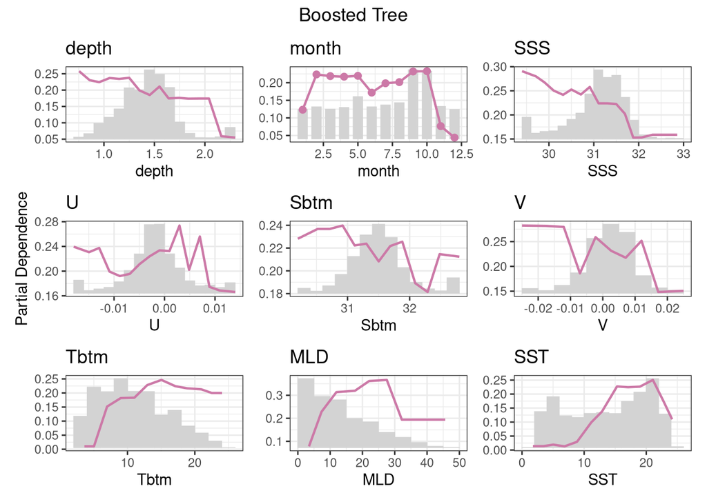

```r
model_fit_pdp(model_fits, wid = "default_btree", title = "Boosted Tree")
```